# project1_conspiracy

```python
!pip install -q spacy sentence-transformers colorcet
```

[output not shown]

```python
!curl -O https://ling583.s3.amazonaws.com/conspiracy.parquet
```

```
  % Total    % Received % Xferd  Average Speed   Time    Time     Time  Current
                                 Dload  Upload   Total   Spent    Left  Speed
  0     0    0     0    0     0      0      0 --:--:-- --:--:-- --:--:--     0
```

[output not shown]

```
100 49.2M  100 49.2M    0     0  6800k      0  0:00:07  0:00:07 --:--:-- 6707k
```

```python
import re
from collections import Counter, defaultdict

import numpy as np
import pandas as pd
import matplotlib.pyplot as plt
import colorcet as cc
import spacy
from cytoolz import concat, partition_all
from tqdm import tqdm
from bokeh.layouts import column
from bokeh.plotting import figure, output_notebook, show
from bokeh.transform import factor_cmap, linear_cmap
from sentence_transformers import SentenceTransformer
from sklearn.decomposition import TruncatedSVD
from sklearn.manifold import TSNE
from sklearn.cluster import HDBSCAN

output_notebook()
```

Loading BokehJS ...

```python
# Load the dataset
df = pd.read_parquet('conspiracy.parquet')
```

```python
# Take a 2,000-post subsample of the data and divide each post into 10-sentence chunks
sentence_splitter = spacy.blank("en")
sentence_splitter.add_pipe("sentencizer")

chunks = pd.DataFrame({'text': [' '.join(batch)
                                for doc in sentence_splitter.pipe(df['text'].sample(2000, random_state=42), n_process=2)
                                for batch in partition_all(10, (s.orth_ for s in doc.sents))]})
```

```python
# Encoding chunks using MiniLM SBERT model
model = SentenceTransformer("all-MiniLM-L12-v2")
full_sbert_vectors = model.encode(list(chunks['text']))
```

```python
# Dimensionality reduction using Truncated SVD
sbert_vectors = TruncatedSVD(n_components=25).fit_transform(full_sbert_vectors)
```

```python
# Reduce to 2D for visualization using t-SNE
tsne = TSNE(n_components=2, random_state=42)
sbert_vectors_2d = tsne.fit_transform(sbert_vectors)
```

```python
# Cluster the chunks using HDBSCAN
clusters = HDBSCAN(min_cluster_size=10, max_cluster_size=500).fit_predict(full_sbert_vectors)
chunks['cluster'] = clusters
```

```python
def plot_projection(proj, title=None):
    plt.scatter(
        proj[:, 0], proj[:, 1], s=3, alpha=0.3
    )
    plt.tick_params(left=False, bottom=False, labelleft=False, labelbottom=False)
    if title:
        plt.title(title)
```

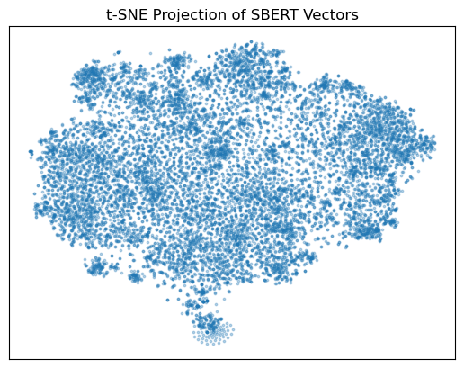

```python
# Plot the projection
plot_projection(sbert_vectors_2d, title='t-SNE Projection of SBERT Vectors')
plt.show()
```

```python
# Visualize the clusters
chunks['x'] = sbert_vectors_2d[:, 0]
chunks['y'] = sbert_vectors_2d[:, 1]
```

```python
from bokeh.transform import linear_cmap

# Define colormap
cmap = linear_cmap("cluster", palette=cc.glasbey, low=0, high=chunks['cluster'].max())

# Create Bokeh plot
p = figure(
    x_axis_type=None,
    y_axis_type=None,
    tools="pan,wheel_zoom,box_zoom,zoom_in,zoom_out,hover,save,reset,help",
    tooltips=[("text", "@text")],
    title="Clustered Chunks"
)
scatter = p.scatter(
    "x",
    "y",
    source=chunks.query('cluster != -1'),
    fill_alpha=0.8,
    alpha=0.01,
    radius=0.6,
    fill_color=cmap
)

# Show the plot
show(p)
```

```python
# Keyword Analysis
from sklearn.feature_extraction.text import CountVectorizer
```

```python
# CountVectorizer for keyword analysis
vectorizer = CountVectorizer(max_features=1000)
X = vectorizer.fit_transform(chunks['text'])
```

```python
# Get the top keywords
keywords = vectorizer.get_feature_names_out()

# Display the top keywords
print("Top Keywords:", keywords)
```

[output not shown]

[output cut: 64 more lines]

[output not shown]

```python
# Terminology Extraction (Named Entity Recognition - NER)
# We'll use spaCy for NER
import spacy

nlp = spacy.load("en_core_web_sm")
```

```python
# Concatenate all comment threads into a single text
all_text = ' '.join(df['text'])
```

```python
import pandas as pd
import spacy
import matplotlib.pyplot as plt

# Load the English language model for Named Entity Recognition
nlp = spacy.load("en_core_web_sm")

# Assuming comment threads are stored in a list named 'comment_threads'
comment_threads = [...]  # List of comment threads

# Create a DataFrame with the comment threads
chunks = pd.DataFrame({'text': comment_threads})

# Function to extract unique entities from text
def extract_unique_entities(text):
    doc = nlp(text)
    unique_entities = set()
    for ent in doc.ents:
        unique_entities.add(ent.text)
    return unique_entities

# Apply the function to each comment thread and get unique entities
chunks['unique_entities'] = chunks['text'].apply(extract_unique_entities)

# Merge all unique entities into a single set
all_unique_entities = set()
for entities in chunks['unique_entities']:
    all_unique_entities.update(entities)

# Visualize the top entities mentioned in the comment threads
entity_counts = {}
for entity in all_unique_entities:
    entity_counts[entity] = chunks['text'].apply(lambda x: entity in x).sum()

# Convert the dictionary to a DataFrame and sort the entities by frequency
entity_df = pd.DataFrame(entity_counts.items(), columns=['Entity', 'Frequency'])
entity_df = entity_df.sort_values(by='Frequency', ascending=False).head(10)

# Plot the top entities
plt.figure(figsize=(10, 6))
plt.bar(entity_df['Entity'], entity_df['Frequency'], color='skyblue')
plt.xlabel('Entity')
plt.ylabel('Frequency')
plt.title('Top Entities Mentioned in Comment Threads')
plt.xticks(rotation=45)
plt.show()
```

[output not shown]

```python
# Function to perform Named Entity Recognition (NER) and filter entities
def extract_entities(text):
    doc = nlp(text)
    unique_entities = set()
    for ent in doc.ents:
        # Filter entities based on types of interest
        if ent.label_ in ['ORG', 'PERSON', 'GPE']:
            relevant_entities.append(ent.text)
    return relevant_entities

# Split the text into chunks to avoid memory issues
chunk_size = 100000  # You can adjust the chunk size as needed
chunks = [all_text[i:i+chunk_size] for i in range(0, len(all_text), chunk_size)]

# Apply NER and filter relevant entities to each chunk of text
relevant_entities = []
for chunk in chunks:
    relevant_entities.extend(extract_entities(chunk))

# Display the extracted relevant entities
print(relevant_entities)
```

```
KeyboardInterrupt
```

```python
#Function to extract entities
def extract_entities(text):
    doc = nlp(text)
    entities = [ent.text for ent in doc.ents if ent.label_ == "PERSON" or ent.label_ == "ORG"]
  return entities
```

```python
# Extract entities from chunks
chunks['entities'] = chunks['text'].apply(extract_entities)
```

```python
!pip install gensim
```

[output not shown]

```
     ━━━━━━━━━━━━━━━━━━━━━━━━━━━━━━━━━━━━━━━━ 24.0/24.0 MB 31.4 MB/s eta 0:00:0000:0100:01
```

```python
# Topic Modeling (Latent Dirichlet Allocation - LDA)
from gensim import corpora, models
```

```python
import spacy

# Load the English language model
nlp = spacy.load("en_core_web_sm")

# Define a tokenization function
def tokenize_text(text):
    doc = nlp(text)
    tokens = [token.text for token in doc]
    return tokens

# Tokenize the text and store tokens in a new column 'tokens'
chunks['tokens'] = chunks['text'].apply(tokenize_text)

print(chunks.head())
```

```
                                                text  cluster          x  \
0  SS: A very high number of very small parcels o...       -1   7.897085
1  It usually isn’t a lot of money… especially in...       -1  51.190243
2  Mr ouchi All the more reason to discount the e...       -1  50.773205
3  i know you're trying to turn his idea of takin...       -1  -2.172953
4  Seems like the tyrannical Fujimori dictatorshi...       -1 -26.239967

           y                                             tokens
0  66.916954  [SS, :, A, very, high, number, of, very, small...
1  25.126003  [It, usually, is, n’t, a, lot, of, money, …, e...
2  25.556015  [Mr, ouchi, All, the, more, reason, to, discou...
3  37.812099  [i, know, you, 're, trying, to, turn, his, ide...
4  50.605019  [Seems, like, the, tyrannical, Fujimori, dicta...
```

```python
# Create a dictionary from the tokens
dictionary = corpora.Dictionary(chunks['tokens'])

# Create a corpus
corpus = [dictionary.doc2bow(tokens) for tokens in chunks['tokens']]
```

```python
# Apply LDA
lda_model = models.LdaModel(corpus, num_topics=5, id2word=dictionary, passes=15)
```

```python
# Display the topics
for idx, topic in lda_model.print_topics(-1):
    print("Topic {}: {}".format(idx, topic))
```

```
Topic 0: 0.050*"." + 0.027*"the" + 0.026*"," + 0.023*"to" + 0.019*"a" + 0.018*"and" + 0.016*"you" + 0.015*"I" + 0.013*"of" + 0.013*"it"
Topic 1: 0.046*"*" + 0.013*""" + 0.012*"this" + 0.012*")" + 0.010*"bot" + 0.010*"of" + 0.010*"concerns" + 0.009*"reddit" + 0.009*"automatically" + 0.008*"Please"
Topic 2: 0.050*"." + 0.038*"the" + 0.028*"," + 0.024*"to" + 0.019*"and" + 0.019*"a" + 0.017*"of" + 0.016*"is" + 0.015*"I" + 0.014*"that"
Topic 3: 0.036*"," + 0.029*"the" + 0.023*"of" + 0.023*"U_R_L" + 0.021*"-" + 0.015*":" + 0.013*"." + 0.013*"in" + 0.010*"The" + 0.009*"*"
Topic 4: 0.156*"*" + 0.027*"a" + 0.023*"statement" + 0.022*"you" + 0.017*"," + 0.017*"submission" + 0.017*"." + 0.014*"not" + 0.011*"and" + 0.011*":"
```

```python
# Clustering (K-means)
from sklearn.cluster import KMeans
```

```python
# Check the lengths of X and chunks
print("Number of rows in X:", X.shape[0])
print("Length of chunks:", len(chunks))
```

```
Number of rows in X: 12549
Length of chunks: 12549
```

```python
# Truncate chunks to match the length of X
chunks = chunks.iloc[:X.shape[0]]

# Verify that the lengths match
assert X.shape[0] == len(chunks), "Number of rows in X and length of chunks do not match"

# Fit KMeans clustering
kmeans = KMeans(n_clusters=5, random_state=42)
chunks['cluster'] = kmeans.fit_predict(X)
```

```python
print("Clusters:", chunks['cluster'].unique())
```

```
Clusters: [3 1 4 2 0]
```

```python
import matplotlib.pyplot as plt
from wordcloud import WordCloud
```

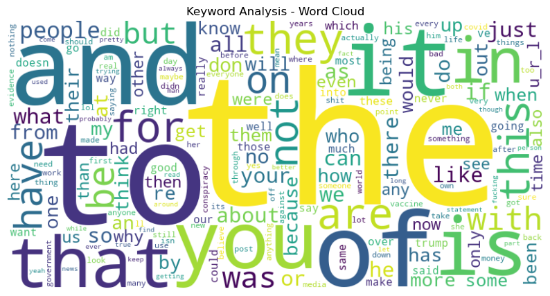

```python
# Visualize Keyword Analysis (Word Cloud)
word_freq = dict(zip(keywords, X.sum(axis=0).tolist()[0]))
wordcloud = WordCloud(width=800, height=400, background_color='white').generate_from_frequencies(word_freq)

plt.figure(figsize=(10, 6))
plt.imshow(wordcloud, interpolation='bilinear')
plt.axis('off')
plt.title('Keyword Analysis - Word Cloud')
plt.show()
```

[figure not shown]

```python
# Load the English language model for Named Entity Recognition
nlp = spacy.load("en_core_web_sm")

# Perform Named Entity Recognition and store the extracted entities in a new column 'entities'
chunks['entities'] = chunks['text'].apply(lambda x: [ent.text for ent in nlp(x).ents])

# Visualize the top entities mentioned in the comment threads
entities = chunks['entities'].explode().value_counts().head(10)
```

```python
unique_entities = set()
for chunk in chunks['text']:
  for ent in nlp(chunk).ents:
    unique_entities.add(ent.text)
```

```python
plt.figure(figsize=(10, 6))
entities.plot(kind='bar', color='skyblue')
plt.xlabel('Entity')
plt.ylabel('Frequency')
plt.title('Top Entities Mentioned in Comment Threads')
plt.xticks(rotation=45)
plt.show()
```

```
Topic 1 :
['.', 'the', ',', 'to', 'a', 'and', 'you', 'I', 'of', 'it']

Topic 2 :
['*', '"', 'this', ')', 'bot', 'of', 'concerns', 'reddit', 'automatically', 'Please']

Topic 3 :
['.', 'the', ',', 'to', 'and', 'a', 'of', 'is', 'I', 'that']

Topic 4 :
[',', 'the', 'of', 'U_R_L', '-', ':', '.', 'in', 'The', '*']

Topic 5 :
['*', 'a', 'statement', 'you', ',', 'submission', '.', 'not', 'and', ':']
```

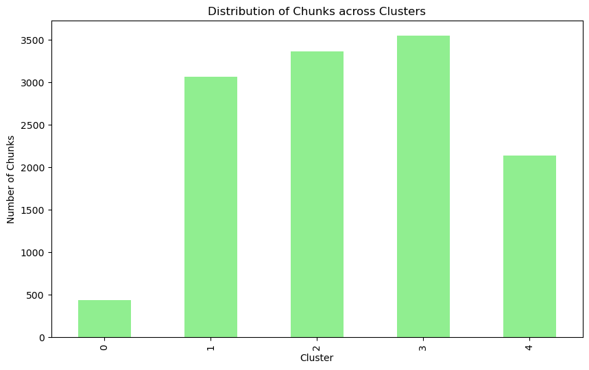

```python
# Visualize Topic Modeling (LDA)
topics = lda_model.show_topics(formatted=False)

for i, topic in topics:
    print("Topic", i+1, ":")
    print([word for word, _ in topic])
    print()

# Visualize Clustering (K-means)
plt.figure(figsize=(10, 6))
chunks['cluster'].value_counts().sort_index().plot(kind='bar', color='lightgreen')
plt.xlabel('Cluster')
plt.ylabel('Number of Chunks')
plt.title('Distribution of Chunks across Clusters')
plt.show()
```

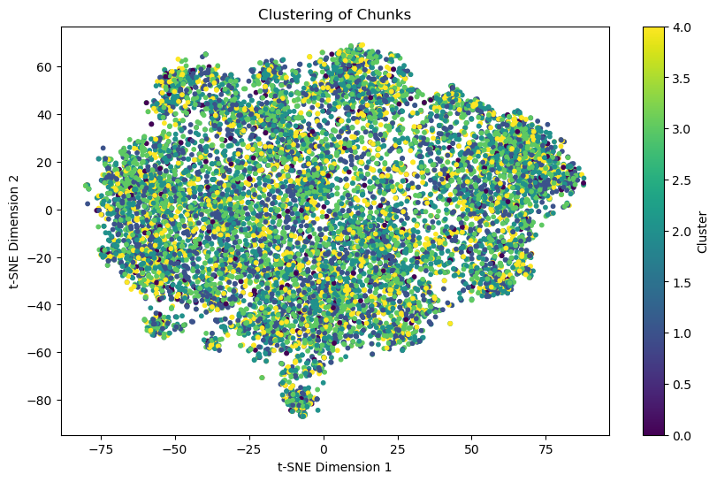

```python
import matplotlib.pyplot as plt

# Visualize Clustering (K-means) using scatter plot
plt.figure(figsize=(10, 6))
plt.scatter(chunks['x'], chunks['y'], c=chunks['cluster'], cmap='viridis', s=10)
plt.xlabel('t-SNE Dimension 1')
plt.ylabel('t-SNE Dimension 2')
plt.title('Clustering of Chunks')
plt.colorbar(label='Cluster')
plt.show()
```

[output not shown]

```
                                                text
0  SS: A very high number of very small parcels o...
1  It usually isn’t a lot of money… especially in...
2  Mr ouchi All the more reason to discount the e...
3  i know you're trying to turn his idea of takin...
4  Seems like the tyrannical Fujimori dictatorshi...
```

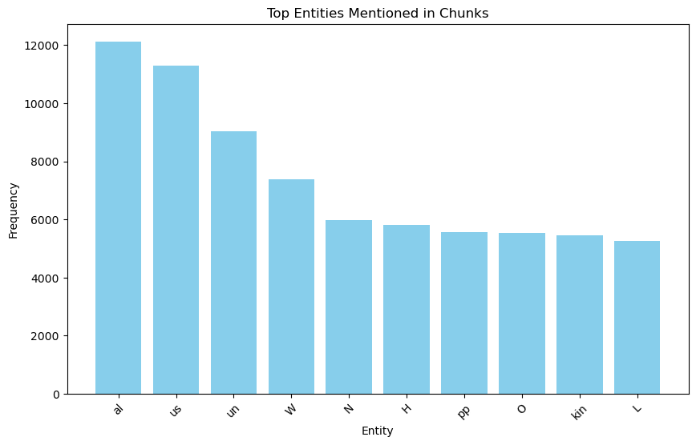

```python
import pandas as pd
import spacy

# Load the English language model for Named Entity Recognition
nlp = spacy.load("en_core_web_sm")

# Load the dataset
df = pd.read_parquet('conspiracy.parquet')

# Load the English language model for sentence splitting
sentence_splitter = spacy.blank("en")
sentence_splitter.add_pipe("sentencizer")

# Take a 2,000-post subsample of the data
subsample_df = df['text'].sample(2000, random_state=42)

# Divide each post into 10-sentence chunks
chunks = []
for doc in sentence_splitter.pipe(subsample_df, n_process=2):
    sentences = [s.orth_ for s in doc.sents]
    for i in range(0, len(sentences), 10):
        chunk = ' '.join(sentences[i:i+10])
        chunks.append(chunk)

# Create a DataFrame with the chunks
chunks_df = pd.DataFrame({'text': chunks})

# Display the DataFrame
print(chunks_df.head())

# Function to extract unique entities from text
def extract_unique_entities(text):
    doc = nlp(text)
    unique_entities = set()
    for ent in doc.ents:
        if ent.label_ in ['ORG', 'PERSON', 'GPE']:  # Filter entities of interest
            unique_entities.add(ent.text)
    return unique_entities

# Apply the function to each chunk and get unique entities
chunks_df['unique_entities'] = chunks_df['text'].apply(extract_unique_entities)

# Merge all unique entities into a single set
all_unique_entities = set()
for entities in chunks_df['unique_entities']:
    all_unique_entities.update(entities)

# Visualize the top entities mentioned in the chunks
entity_counts = {}
for entity in all_unique_entities:
    entity_counts[entity] = chunks_df['text'].apply(lambda x: entity in x).sum()

# Convert the dictionary to a DataFrame and sort the entities by frequency
entity_df = pd.DataFrame(entity_counts.items(), columns=['Entity', 'Frequency'])
entity_df = entity_df.sort_values(by='Frequency', ascending=False).head(10)

# Plot the top entities
import matplotlib.pyplot as plt
plt.figure(figsize=(10, 6))
plt.bar(entity_df['Entity'], entity_df['Frequency'], color='skyblue')
plt.xlabel('Entity')
plt.ylabel('Frequency')
plt.title('Top Entities Mentioned in Chunks')
plt.xticks(rotation=45)
plt.show()
```

```python
import pandas as pd
import spacy
from sklearn.feature_extraction.text import CountVectorizer
from sklearn.decomposition import LatentDirichletAllocation
from sklearn.cluster import KMeans
import matplotlib.pyplot as plt

# Load the English language model for NLP tasks
nlp = spacy.load("en_core_web_sm")
```

```python
# Function to preprocess text using spaCy
def preprocess_text(text):
    doc = nlp(text)
    processed_text = ' '.join([token.lemma_ for token in doc if not token.is_stop and token.is_alpha])
    return processed_text
```

```python
# Apply preprocessing to the text chunks
chunks_df['processed_text'] = chunks_df['text'].apply(preprocess_text)

# Convert text data into a matrix of token counts
vectorizer = CountVectorizer(max_df=0.95, min_df=2, stop_words='english')
X = vectorizer.fit_transform(chunks_df['processed_text'])

# Topic Modeling with Latent Dirichlet Allocation (LDA)
lda_model = LatentDirichletAllocation(n_components=5, max_iter=10, learning_method='online', random_state=42)
lda_topics = lda_model.fit_transform(X)
```

```
Topic 1:
russia ukraine video year white look war israel jews high

Topic 2:
trump post link say news look video president account question

Topic 3:
mask money pay company government wear work buy business public

Topic 4:
vaccine people covid like say know year die death virus

Topic 5:
people like think know right thing want say time way
```

[output not shown]

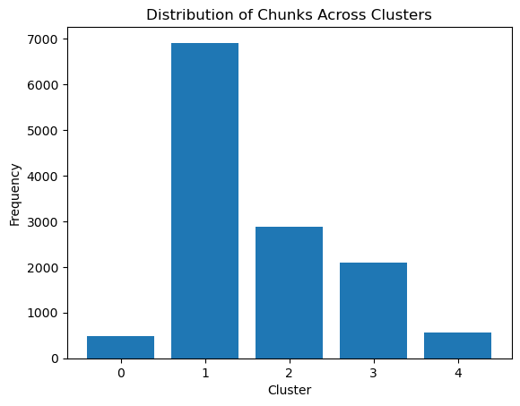

```python
# Display the top words for each topic
def display_topics(model, feature_names, n_top_words):
    for topic_idx, topic in enumerate(model.components_):
        print(f"Topic {topic_idx + 1}:")
        print(" ".join([feature_names[i] for i in topic.argsort()[:-n_top_words - 1:-1]]))
        print()

# Get the feature names
feature_names = vectorizer.get_feature_names_out()

# Display the topics generated by LDA
display_topics(lda_model, feature_names, 10)

# Clustering with K-means
kmeans = KMeans(n_clusters=5, random_state=42)
kmeans.fit(X)

# Visualize the clusters
clusters = kmeans.predict(X)
plt.hist(clusters, bins=range(6), align='left', rwidth=0.8)
plt.xlabel('Cluster')
plt.ylabel('Frequency')
plt.title('Distribution of Chunks Across Clusters')
plt.xticks(range(5))
plt.show()
```

```python
import matplotlib.pyplot as plt
from sklearn.manifold import TSNE
from sentence_transformers import SentenceTransformer
import spacy
from sklearn.decomposition import TruncatedSVD
from sklearn.feature_extraction.text import CountVectorizer
```

```python
# Load the English language model for Spacy
nlp = spacy.load("en_core_web_sm")

# Initialize SBERT model
sbert_model = SentenceTransformer('bert-base-nli-mean-tokens')

# Initialize CountVectorizer for LSA
vectorizer = CountVectorizer()
```

```
config_sentence_transformers.json: 100%|████████| 122/122 [00:00<00:00, 350kB/s]
```

```python
# Assuming 'documents' is a list of documents
documents = df['text'].tolist()
```

```python
# LSA
X_lsa = vectorizer.fit_transform(documents)
lsa_model = TruncatedSVD(n_components=2)
lsa_embeddings = lsa_model.fit_transform(X_lsa)
```

```python
# SBERT
sbert_embeddings = sbert_model.encode(documents)
```

```python
# Function to plot TSNE projection
def plot_tsne_projection(embeddings, perplexity, title):
    tsne = TSNE(n_components=2, perplexity=perplexity, random_state=42)
    embeddings_tsne = tsne.fit_transform(embeddings)
    plt.figure(figsize=(10, 8))
    plt.scatter(embeddings_tsne[:, 0], embeddings_tsne[:, 1], alpha=0.7)
    plt.title(title)
    plt.xlabel('TSNE Component 1')
    plt.ylabel('TSNE Component 2')
    plt.show()
```

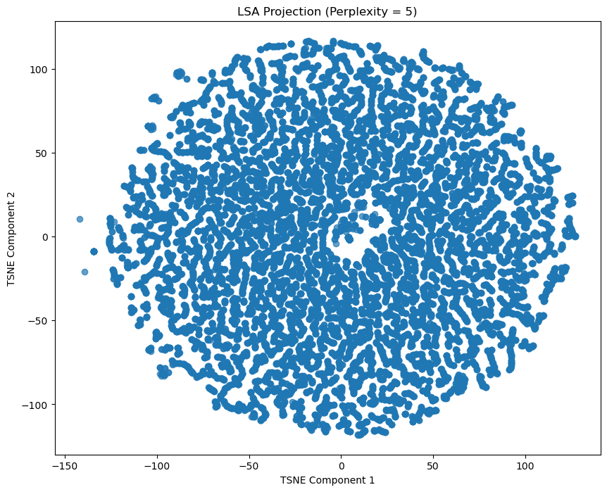

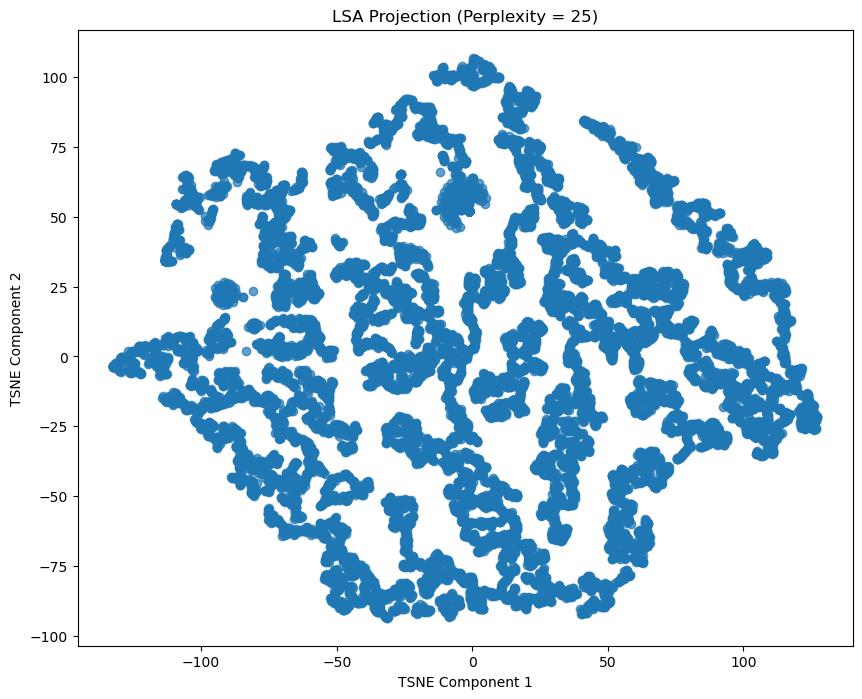

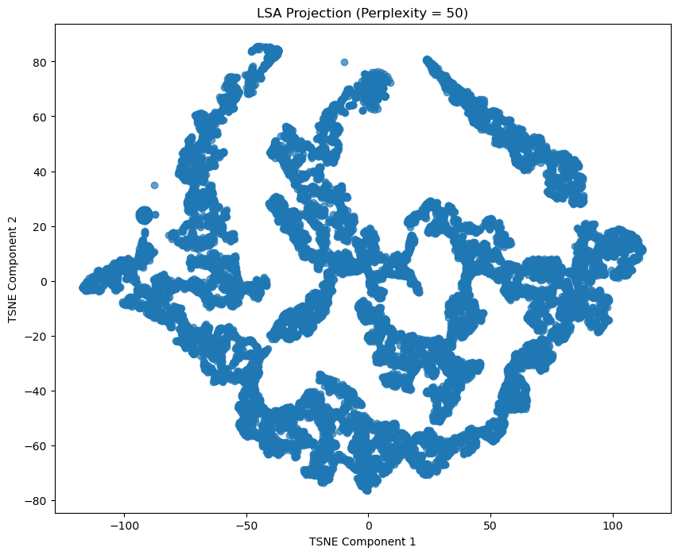

```python
# Plot TSNE projection for LSA with different perplexity values
plot_tsne_projection(lsa_embeddings, 5, 'LSA Projection (Perplexity = 5)')
plot_tsne_projection(lsa_embeddings, 25, 'LSA Projection (Perplexity = 25)')
plot_tsne_projection(lsa_embeddings, 50, 'LSA Projection (Perplexity = 50)')
```

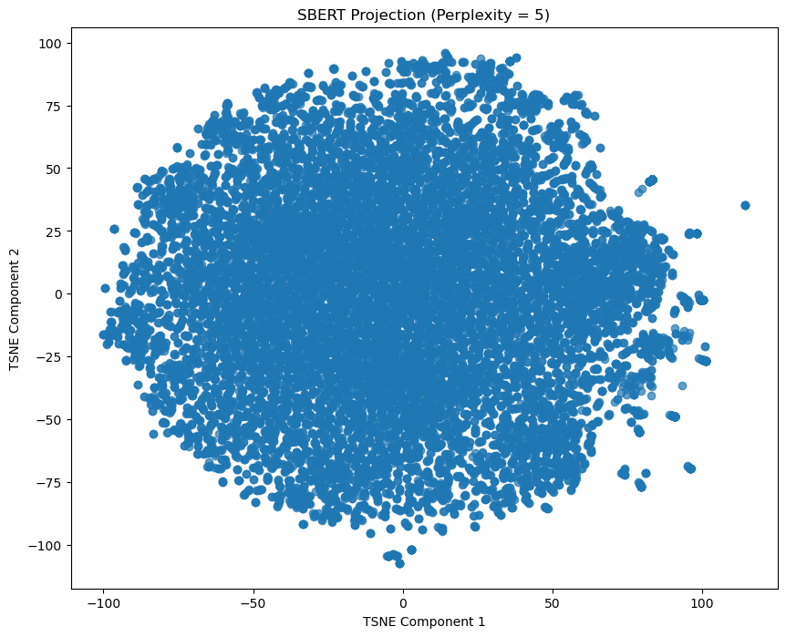

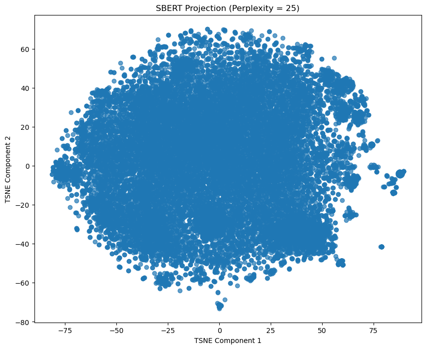

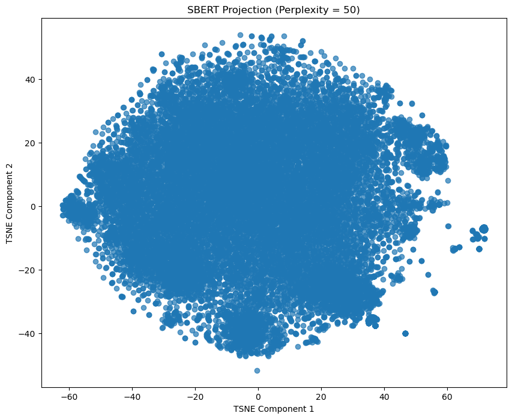

```python
# Plot TSNE projection for SBERT with different perplexity values
plot_tsne_projection(sbert_embeddings, 5, 'SBERT Projection (Perplexity = 5)')
plot_tsne_projection(sbert_embeddings, 25, 'SBERT Projection (Perplexity = 25)')
plot_tsne_projection(sbert_embeddings, 50, 'SBERT Projection (Perplexity = 50)')
```

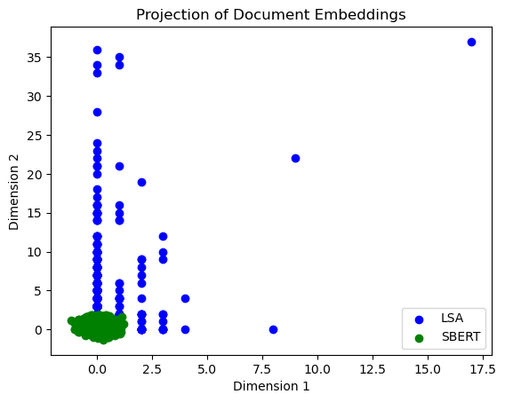

```python
import matplotlib.pyplot as plt
import numpy as np

# Convert sparse matrix to dense array for LSA embeddings
X_lsa_dense = X_lsa.toarray()

# Plot LSA embeddings
plt.scatter(X_lsa_dense[:, 0], X_lsa_dense[:, 1], c='blue', label='LSA')

# Plot SBERT embeddings
plt.scatter(sbert_embeddings[:, 0], sbert_embeddings[:, 1], c='green', label='SBERT')

# Add labels and legend
plt.xlabel('Dimension 1')
plt.ylabel('Dimension 2')
plt.title('Projection of Document Embeddings')
plt.legend()

# Show plot
plt.show()
```

Some observations about the data visualized in the scatter plot:

Topic 1: russia ukraine video year white look war israel jews high

Topic 2: trump post link say news look video president account question

Topic 3: mask money pay company government wear work buy business public

Topic 4: vaccine people covid like say know year die death virus

Topic 5: people like think know right thing want say time way

Here are some observations about the clustering:

Topic Analysis:

Russia-Ukraine: This topic focuses on entities and events related to the ongoing conflict between Russia and Ukraine. Words like "video," "year," "war," and "jews" suggest potential discussions surrounding the war's timeline, media coverage, and its broader geopolitical implications. However, the presence of "jews" raises concern, as it could be associated with harmful stereotypes and anti-Semitic rhetoric, requiring further investigation and responsible interpretation.

Trump: This topic revolves around former US president Donald Trump, mentioning elements like his "post," "link," "news," and "account." This suggests potential discussions covering his social media activity, news articles about him, and questions related to his presidency.

Mask: This topic centers around the use of face masks during the COVID-19 pandemic, with words like "money," "pay," "company," "wear," and "business" pointing to potential discussions on mask mandates, their economic impact, and business regulations.

Vaccine: This topic focuses on the COVID-19 vaccine, with words like "people," "covid," "die," "death," and "virus" indicating potential discussions on vaccine efficacy, public health concerns, and the pandemic's overall impact.

Opinion: This topic appears more general, containing words like "people," "like," "think," "know," "right," and "way," suggesting potential discussions expressing personal opinions, beliefs, and perspectives on various topics.

Additional Considerations:

The presence of emotionally charged words like "war" and "jews" necessitates careful consideration of potential biases and harmful interpretations within the data. The limited context makes it difficult to assess the overall sentiment or tone associated with these topics. Depending on the data source and model used, these topics might not necessarily represent the most prevalent or important themes present in the data.